# Directed Graph Metrics

2022-01-02

There are a number of graph metrics that makes the most sense to compute in **directed graphs**. In this chapter, we discuss the most important ones.

# 1 Graph Hierarchy

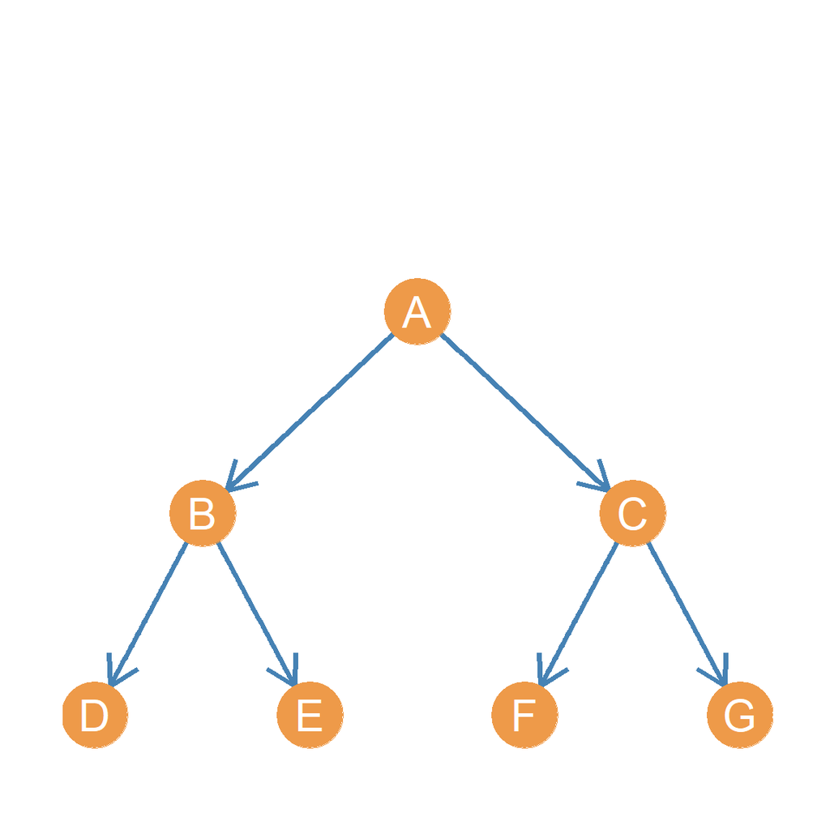

Figure 1.1: A tree graph.

Table 1.1: Reachability matrix for an anti-symmetric tree graph.

|  | A | B | C | D | E | F | G |
| --- | --- | --- | --- | --- | --- | --- | --- |
| A | – | 1 | 1 | 1 | 1 | 1 | 1 |
| B | 0 | – | 0 | 1 | 1 | 0 | 0 |
| C | 0 | 0 | – | 0 | 0 | 1 | 1 |
| D | 0 | 0 | 0 | – | 0 | 0 | 0 |
| E | 0 | 0 | 0 | 0 | – | 0 | 0 |
| F | 0 | 0 | 0 | 0 | 0 | – | 0 |
| G | 0 | 0 | 0 | 0 | 0 | 0 | – |

Now if we look at *A*’s *column*, we see that it is full of zeroes, indicating that while *A* can reach everybody, no one can reach them back. The same goes for every level; the nodes at the top can reach the ones at the bottom, but they can’t reach them back. This is why the lower triangle of the matrix has to be made up of all zeroes.

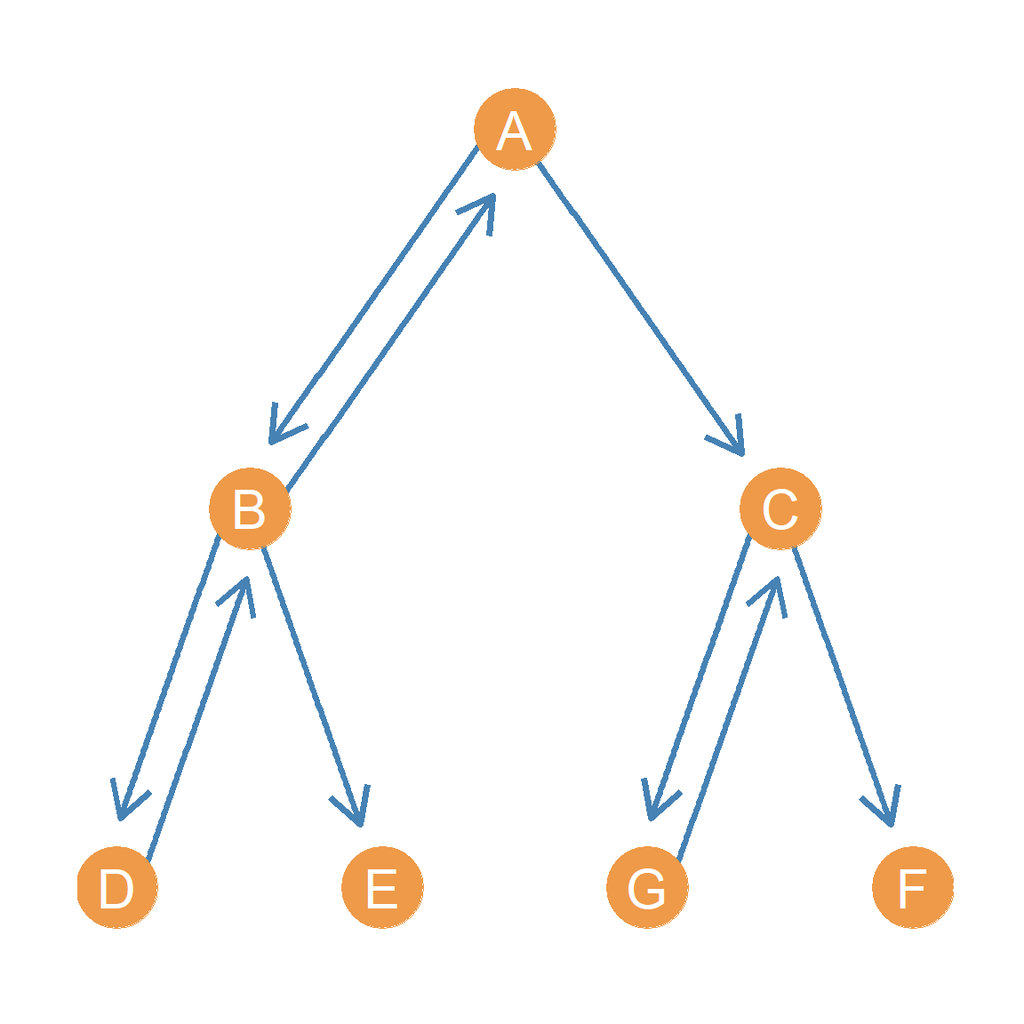

Figure 1.2: An asymmetric graph arranged as a tree.

Now let’s break the anti-symmetry principle and add some reciprocal directed ties to the network shown in Figure 1.1, keeping the same set of nodes. This transforms the graph from an anti-symmetric to an asymmetric one. The new graph is shown as Figure 1.2. In this network, node *B* sends a reciprocal link to *A*, node *D* sends a reciprocal link to *B*, and *G* reciprocates their tie to **C*. The reachability matrix for this graph, is shown in table 1.2.

|  | A | B | C | D | G | E | F |
| --- | --- | --- | --- | --- | --- | --- | --- |
| A | – | 1 | 1 | 1 | 1 | 1 | 1 |
| B | 1 | – | 1 | 1 | 1 | 1 | 1 |
| C | 0 | 0 | – | 0 | 1 | 0 | 1 |
| D | 1 | 1 | 1 | – | 1 | 1 | 1 |
| G | 0 | 0 | 1 | 0 | – | 0 | 1 |
| E | 0 | 0 | 0 | 0 | 0 | – | 0 |
| F | 0 | 0 | 0 | 0 | 0 | 0 | – |

Note that one big difference between Tables 1.1 and 1.2 is that Table 1.2 now features some non-zero entries in the lower-triangle. So it seems like the lower triangle in the reachability matrix of an asymmetric graph, records *anti-symmetry violations*.

Another big difference between Tables 1.1 and 1.2 is that now nodes *B* and *D*, like *A* in the original tree graph, can reach everybody else in the network. They can do that because now they can reach *A*, and since *A* could reach everyone initially, they can do so through that node.

$$\begin{equation}
H(G) = 1 - \frac{\sum_i \sum_j d^r_{ij}d^r_{ji}}{\frac{1}{2}\sum_i \sum_j d^r_{ij}}
\tag{1.1}
\end{equation}$$

There are several measures that can be implemented to capture whether more or less hierarchy is prevailing within a network. Connectedness measures the reachability of nodes in an undirected graph. Conversely, hierarchy measures the reachability in a directed graph. The measures are calculated with the same equation, but their interpretation and what constitutes *V* is quite different! Connectedness measures reachability, while hierarchy measures the violations of transitivity in a network. Finally, reciprocity measures the percentage of ties in a directed network that are part of a reciprocal relationship.

# 2 Connectedness

Using a reachability matrix, connectedness is premised on asking if any given nodes are able to reach one another through a path of some finite length. *Connectedness* is a measure of the percentage of nodes in an undirected graph that are able to reach one another. Reachability, and thus connectedness is a measure of the transitivity of the relationship to non-directly connected others. A might not know C, but as A knows B and B knows C, A is able to still reach C through B, and thus there is a degree of transitivity to the relationship of knowing. We have previously mentioned how this is important in questions of indirect influence as opposed to direct influence.

As discussed earlier, a reachability matrix has a cell marked 1 if to nodes are able to reach one another, and 0 if two nodes are unable to reach one another. Therefore, we can count the number of 0’s in a matrix, divide by 2, and this is the number of pairs of nodes that are unable to reach each other. One can also simply count the number of 0’s below (or above!) the diagonal, as the matrix is symmetric so the result will be the same. The number of node pairs that are not able to reach one another are violations of connectivity. The number of these violations in the network are inserted into the equation as *V*.

The equation for connectedness is simply 1 minus the percentage of violations of connectivity. When subtracting the number of violations of connectivity (V) divided by the total number of possible connections (N(N-1)/2), the result is the percentage of nodes that are able to reach one another through some finite pathlength.

Thus, when the connectedness is C=1, there is complete connectivity in the graph. Every node can reach every other node through a path of some length. Conversely, a connectivity score of 0 would mean that no nodes can reach any other nodes through a path of some length. If we have a score of 0, this would mean that the network has no edges connecting nodes, and thus no nodes can reach any other node.

Notice that density measures the frequency of connections, while connectedness simply measures the frequency of a path of some length between nodes. A network could have high density and low connectivity, or high connectivity and low density for example! The network could also have high density and connectivity, and low density and connectivity. Putting both measures together can be useful for the theoretic interpretation of a network!

# 3 Hierarchy

While connectedness looks at an undirected graph, hierarchy is a consideration in directed graphs. Like connectedness, hierarchy looks at a reachability matrix and looks for violations of reachability. *Hierarchy* is the percentage of ties that do not violate transitivity in a directed network.

Depending on the question we are interested in, hierarchy can be interpreted in two ways. First, if one is interested in measuring a lack of transitivity in authority relations, then a high hierarchy score means that there are high levels of transitivity. There are low levels of violations of the status order when hierarchy is high. Second however, if you are interested in the mutual reachability of nodes in a directed graph, the measure can be interpreted as a low H score indicating higher degrees of connectivity. For example, if we had a friendship network where hierarchy was less of a theoretic concern than the transfer of information, we might be interested in groups with lower H scores, as this indicates a higher degree of reciprocal connections than a group with a higher H score. Thus, depending on the theoretic concern, the same H score can have different interpretations.

In a reachability matrix, the violations of hierarchy occur if both column *i,j* and _j,i _are equal to 1. Remember that row’s *i* send reachability to columns _j _in a reachability matrix. If that same *j* sends a tie to column *i*, that indicates reciprocity which is a violation of the inequality inherent in hierarchy. Thus, violations can be found by looking for 1’s in the reachability matrix that occur in both column *i,j* and *j,i*. Each of the two 1’s count as a separate violation, meaning that each violation is worth 2 in terms of calculating V.

Similar to the connectedness measure, the number of hierarchy violations (V) is divided by the number of possible ties (N(N-1)/2) and then subtracted from 1. Thus, the resulting measure is the percentage of ties that conform to the expectations of hierarchy. A network with no violations would have a score of H=1, while a network with only violations would be equal to 0.

# 4 Reciprocity

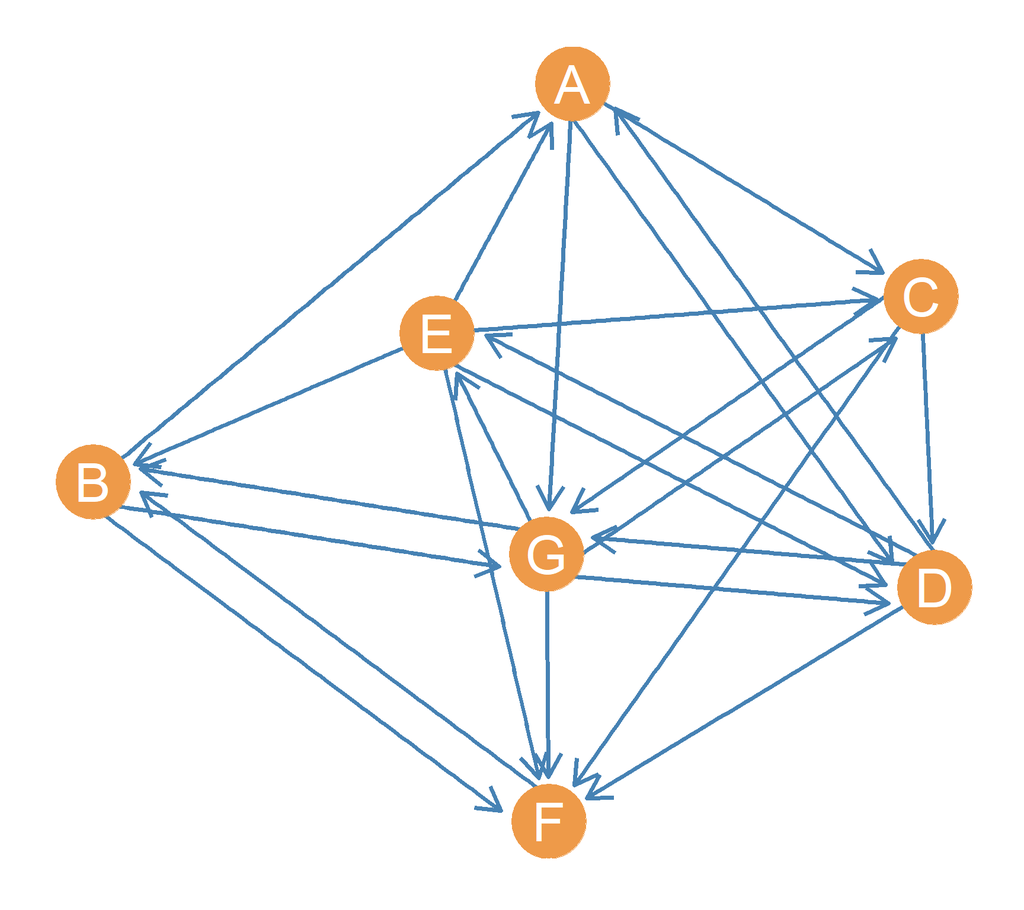

Figure 4.1: A directed graph.

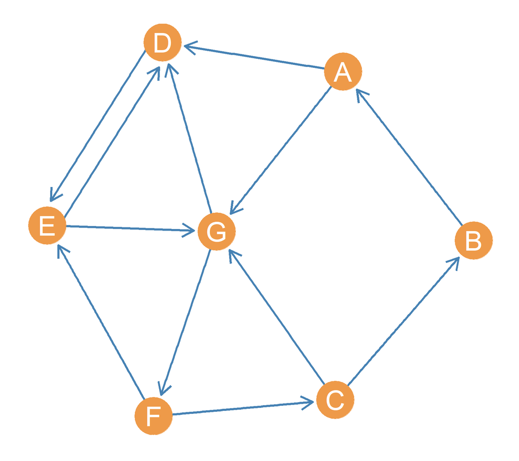

Figure 4.2: Another directed graph.

Remember from our discussion in the lesson types of graphs, that a key difference between undirected and directed graphs, is that they allow for possibly non-reciprocal links between dyads. That is while dyads in an undirected graph can either be **null** or **connected**, connected dyads in directed graphs, can be either **asymmetric** or **mutual**. This means that not all directed graphs are created the same. Some of them, like the graph shown in Figure 4.1 feature many mutual dyads (drawn as double-headed arrows), while others, like the graph shown in Figure 4.2 just have many asymmetric dyads (drawn as single-headed arrows). As such, it would be useful to have a summary metric telling us the extent to which mutual dyads featuring reciprocal ties dominate the network. Ideally, such a metric should be at a maximum (e.g. 1.0), when all dyads are mutual, and at minimum when all dyads are asymmetric.

This metric exists and it is called the **graph reciprocity**. It can be computed from the asymmetric adjacency matrix of the corresponding directed graph.

Out of all the ties in the network, what percentage of those ties are involved in a reciprocal relationship? *Reciprocity* measures the percentage of ties in a directed network that are part of a reciprocal relationship.

Unlike hierarchy, which uses a reachability matrix, reciprocity uses an adjacency matrix. It thus directly asks about two connected nodes in a directed network. Reciprocity is measured by taking the number of ties involved in a reciprocal relationship (V), and dividing by the total number of ties (E).

Edges that are part of a reciprocal relationship (V) can be counted individually. Thus, for a reciprocal dyad, there are 2 edges that are part of the reciprocal relationship, despite it being only 1 reciprocal relationship.

For example, a tree graph should have a reciprocity where R=0. This is because for anti-symmetric ties, it is impossible for there to be any reciprocity in the relations. For a graph with complete reciprocity in all ties, then R=1. However, for a graph with 6 edges, 4 of which are part of a reciprocal relationship and 2 that are not, then the reciprocity is R=4/6=.66.

Imagine a network with a high degree of reciprocity compared to a network with a low degree of reciprocity. The network with the high reciprocity might be happier due to a sense of mutual community, or the actors that compose the network might be more equal in terms of their underlying “quality,” requiring less deference for connections to form. Many other interpretations might be possible, as depending on the theoretic question and outcome of interest, the measure of reciprocity might be used to reach creative insights into the network!